# Assignment 01

Author

Alex Plotnikov

# 1 Exercise 01

## 1.1 Set up SSH authentication between your computer and your GitHub account.

Git is an important part of the development process. It is a version control system that tracks any changes made to the project. It allows a developer to comment any changes, revert the project to previous versions, and facilitate working in groups on complex projects. The [Youtube video](https://www.youtube.com/watch?v=RGOj5yH7evk) that is listed in the [Project Management](https://statds.github.io/ids-f25/git.html) section of the class notes was a great introduction.

I am working on a Mac so Git was already installed on my computer. The instructions below are for Mac users.

Setting up SSH authentication between your computer and GitHub account allows you to securely communciate with a remote repository. I did do some steps differently than general instructions and I will note where this happened.

The first step is to generate an SSH key on your computer.

### 1.1.1 Generating SSH key

1. Open a terminal on your computer. This is found in Applications/Utilities. I recommened keeping the terminal in your dock for easier access later.
2. Now you can run the following command to generate the SSH key:
   - `ssh-keygen -t ed25519 -C "email@example.com"`
     - `ssh-keygen`: this is the function to create a key.
     - `-t ed25519`: this specifies the type of key (ed25519).
     - `-C "email@example.com"`: adds a comment to your key to help with identification in the future.
   - After this command, there will be few prompts:
     - “Enter file in which to save the key”: you can press Enter to save it in the default file location ~/.ssh/id_ed25519. The .ssh folder is a hidden folder where all of your SSH keys will be stored. You can toggle hidden files and folders by pressing Command + Shift + Period in Finder.  
       The “id_ed25519” is the default key name. If at a later time, you generate another key without specifying a name, you will be prompted whether or not you would like to overwrite the key.  
       There are instructions below on naming keys.
     - Enter and re-enter passphrase: adds a layer of security and encrypts the key on your hard drive.
   - Now you will see two keys in your .ssh folder: id_ed25519 (private key) and id_ed25519.pub (public key). DO NOT SHARE PRIVATE KEY WITH ANYONE. When using any service, always provide the .pub key.

   Due to potentailly overwriting keys, perhaps needing multiple keys, or just wanting to know how to name keys, I tried to name my key and the steps were slightly different.

   To generate a named key, the steps are similar except for the initial command you enter into the terminal:
   - `ssh-keygen -t ed25519 -f ~/.ssh/my_key_name -C "email@example.com"`:
     - `-f ~/.ssh/my_key_name`: this is the only difference from the command above. It specifies the key name. Enter your own key name in place of “my_key_name”.
3. Now we can add our key to an SSH Agent. This step is optional and does not impact your ability to interact with a remote repository. The SSH Agent just holds your keys in memory so you do not have to enter in your passphrase for every connection to a remote repository. I did not use an SSH Agent. To add keys to SSH Agent, you have to input the following two commands into your terminal:
   - `eval "$(ssh-agent -s)"`: this command starts the agent. You can check if agent is already running with `ssh-add -l`. If it is not running you will receive the message “Could not open a connection to your authentication agent.”
   - `ssh-add ~/.ssh/id_ed25519`: this will add your key to agent, where “id_ed25519” is the default key name. If you named your key, you would have to input `ssh-add ~/.ssh/my_key_name`.

### 1.1.2 Set up GitHub account

We will momentarily step away and set up our [GitHub](https://github.com/) account. Click Sign Up on the website, this process is similar to any other account and I do not believe warrants any steps.

### 1.1.3 Add SSH key to GitHub Account

1. Now that we have set up our GitHub account, we can proceed to add our previously generated key to our account. We should begin by clicking our profile picture in our GitHub account and clicking **Settings** and afterwards going into **SSH and GPG Keys**. You will see a **New SSH key** button and we can click it now to bring us to the screen where we add our key.
2. We will quickly hop over to our terminal and enter `cat ~/.ssh/id_ed25519.pub`. This copies our key to the clipboard.  
   It should be noted that the public key is being copied, not the private key.  
   Also, if you named your key you will have to change “id_ed25519.pub” to your key name.
3. Now we can go over to the GitHub page to input our key. You can give the key a name in the Title field and paste your public key into the Key field. Now your key should be added to your GitHub Account

### 1.1.4 Verifying your SSH connection to GitHub

1. This is the final step in setting up SSH authentication between your computer and GitHub account. There are two steps below, one for a generated key and the other if you named your key:
   - `ssh -T git@github.com`: this will test the connection between your unnamed key.
   - `ssh -i ~/.ssh/my_key_name -T git@github.com`: this is for your named key, replace “my_key_name” with your key. It should be noted that the key you are using here is your private key, and does not include .pub.
2. In examples I have seen, this usually verifies the connection and everything is good to go. However, I received the following message:

   > The authenticity of host ‘github.com (140.82.112.4)’ can’t be established. ED25519 key fingerprint is SHA256:+DiY3wvvV6TuJJhbpZisF/zLDA0zP… Are you sure you want to continue connecting (yes/no/[fingerprint])?

   This message is a security warning that your computer has never connected to GitHub and needs to verify its identity. Some sources online say you can just type yes, but I think it would be good to verify this is the correct connection. You can visit [GitHub’s SSH key fingerprints](https://docs.github.com/en/authentication/keeping-your-account-and-data-secure/githubs-ssh-key-fingerprints) to see their different public keys. From this website, you can copy their Ed25519 key and paste it into your terminal. If it is a match, then everything should be good.  
   You may be asked to enter your passphrase if you are not running an SSH Agent.

## 1.2 Install Quarto onto your computer following the instructions of Get Started

This step is fairly straightforward and follows a similar installation process to other programs. The code in the following steps uses VS Code and now we are setting up our computers to be able to use .qmd files in VS Code. First, we must install Quarto on our computers, it can be found in this link: [Get Started](https://quarto.org/docs/get-started/). You can choose your operating system and follow the installation steps.

## 1.3 Pick a tool of your choice (e.g., VS Code, Jupyter Notebook, Positron, Emacs, etc.), follow the instructions to reproduce the example of line plot on polar axis.

After the installation, we can pick an IDE of our choice. The code below uses VS Code. There are a couple of steps before we can follow along with the instructions on [Tutorial: Hello, Quarto](https://quarto.org/docs/get-started/hello/vscode.html).

### 1.3.1 Install VS Code Quarto extension

This is another straightforward step where we can navigate to the **Extensions** tab in VS Code and search for Quarto.  
Click the **Install** button after finding Quarto and VS Code should be all set.

### 1.3.2 Setting up Python virtual environment

The code in the Quarto tutorial uses Python as well as specific packages. It is best practice to set up a virtual environment and install any specific packages needed.  
This allows for easier management of packages and dependencies, ensuring your code will run and not be affected by any updates outside of the isolated environment.  
It also makes it easier to reproduce projects by having specific versions installed in the isolated environment.

1. In your terminal, navigate to your project’s root directory.  
   I made the mistake of setting up my virtual environment in the project directory but it has to be set up in the directory above.  
   This way VS Code will be able to recognize it. Now we can complete the following steps in the terminal:
   - `python3 -m venv .venv`: this creates the virtual environment in the directory. `.venv` is the name of the environment and will allow VS Code to recognize it.
   - `source .venv/bin/activate`: this command will activate the virtual environment. You should see that the terminal prompt will have `(.venv)` in the beginning.
2. Now we can install any specific packages we would like.  
   We are going to set up the requirements.txt packages found in the class repository:
   - `pip install -r requirements.txt`: installs all packages found in the txt file. This txt file should be stored in the same directory as the virtual environment.
3. Next we will select the the virtual environment in VS Code. Press Command + Shift + P to open the Command Palette. Here you can type in **Python: Select Interpreter**.  
   You should see your virtual environment as one of the options, mine came up as *Python 3.13.7 (‘.venv’:venv)*.

### 1.3.3 Quarto tutorial

Now that we have set up our virtual environment and packages, we can go through the tutorial.

1. Copy and paste the code in the tutorial into a new hello.qmd file. It should generate the code and image below.

For a demonstration of a line plot on a polar axis, see Figure 1.

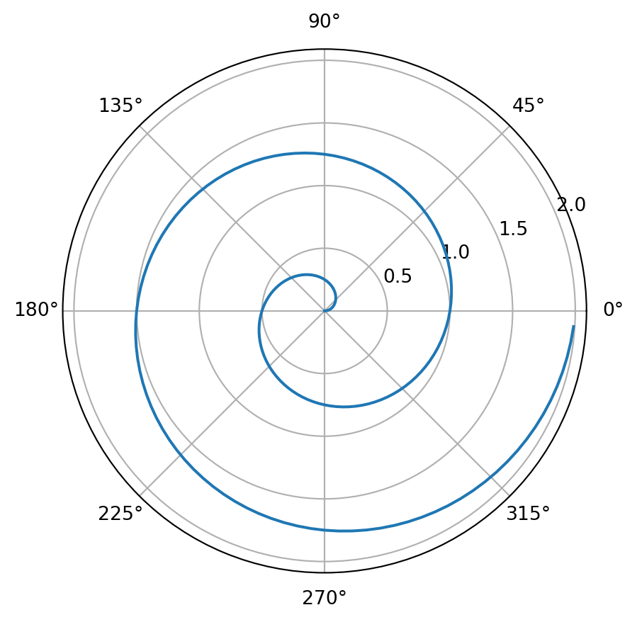

Figure 1: A line plot on a polar axis

```python
import numpy as np
import matplotlib.pyplot as plt

r = np.arange(0, 2, 0.01)
theta = 2 * np.pi * r
fig, ax = plt.subplots(
  subplot_kw = {'projection': 'polar'}
)
ax.plot(theta, r)
ax.set_rticks([0.5, 1, 1.5, 2])
ax.grid(True)
plt.show()
```

2. Next it asks to install dependencies but we should be all set in our virtual environment.
3. Goes over how rendering works with a .qmd file:

   > When you render a .qmd file with Quarto, the executable code blocks are processed by Jupyter, and the resulting combination of code, markdown, and output is converted to plain markdown. Then, this markdown is processed by Pandoc, which creates the finished format.
4. Asks you to make the following small change to your code `theta = 4 * np.pi * r`. This should result in the image below:

For a demonstration of a line plot on a polar axis, see Figure 2.

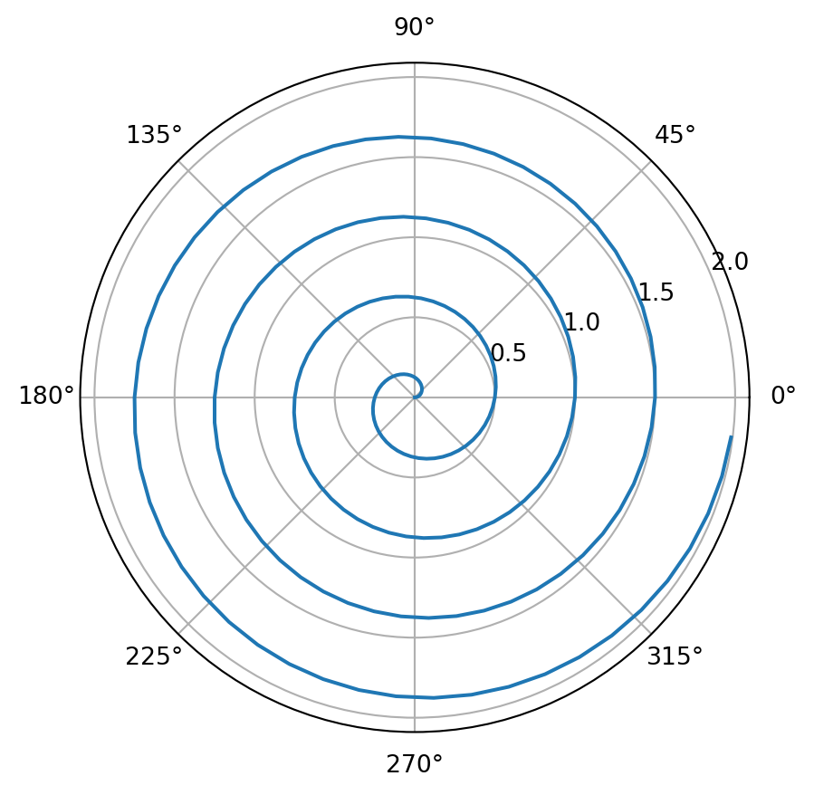

Figure 2: A line plot on a polar axis

```python
import numpy as np
import matplotlib.pyplot as plt

r = np.arange(0, 2, 0.01)
theta = 4 * np.pi * r
fig, ax = plt.subplots(
  subplot_kw = {'projection': 'polar'}
)
ax.plot(theta, r)
ax.set_rticks([0.5, 1, 1.5, 2])
ax.grid(True)
plt.show()
```

5. Tutorial also shows that you do not need to generate the entire document, you can just click **Run Cell** in the .qmd file.
6. YAML options allow you to either hide your code as shown above or display it. This homework assignment has code-fold as True so my code snippets will be hidden.
7. We can create headings using two ## signs.
8. Finally goes over details of the code cell options as well as options to preview the document externally.

## 1.4 Render the homework into a HTML.

There are ways to do this through VS Code but we will render our homework through the terminal.

1. We must make sure our virtual environment is still active.
2. Navigate through the terminal to the directory where the .qmd homework file is located.
3. In the terminal use `quarto render your_file.qmd` to create HTML version.
4. When you open the HTML it may look like an older website instead of the preview format that is given by VS Code. I noticed this as I re-ran the render before upload, did not have any issues before. You will also notice the message: “No TeX installation was detected”. To resolve this, you just have to run `quarto install tinytex` and render your file again. Due to the homework template listing PDF as a format, this will actually also create a PDF during the render.

## 1.5 Print the HTML file to a pdf file and put the file into a release in your GitHub repo.

For this step, I initially opened the HTML in a browser and printed the PDF. Afterwards, I find steps to do this through the terminal:

1. Install wkhtmltopdf using Homebrew: `brew install wkhtmltopdf`.
2. In the directory where the HTML is located run `wkhtmltopdf input_file.html output_file.pdf`.

However, after installing tinytex, the PDF is created due to the format specified in the homework template.

After saving the PDF, go to GitHub and click on **Create a new release** in the GitHub repository. Add any titles or notes, and attach the PDF. Click **Publish release**.